# ALLLife Bank - customer segmentation - unsupervised learning

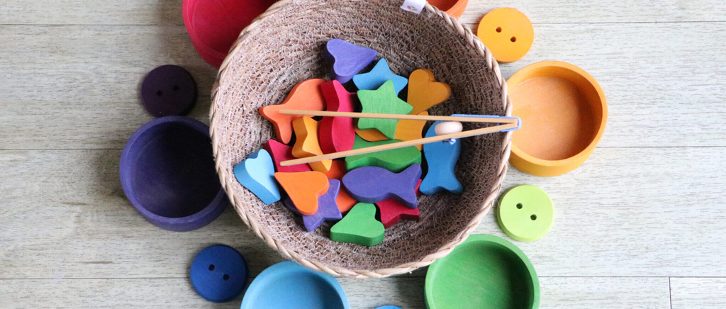

## Context:

AllLife Bank wants to focus on its credit card customer base in the next financial year. They have been advised by their marketing research team, that the penetration in the market can be improved. Based on this input, the Marketing team proposes to run personalized campaigns to target new customers as well as upsell to existing customers. Another insight from the market research was that the customers perceive the support services of the back poorly. Based on this, the Operations team wants to upgrade the service delivery model, to ensure that customer queries are resolved faster. Head of Marketing and Head of Delivery both decide to reach out to the Data Science team for help

## Objective

To identify different segments in the existing customer, based on their spending patterns as well as past interaction with the bank, using clustering algorithms, and provide recommendations to the bank on how to better market to and service these customers.

## Key Questions to answers

1. How many different segments of customers are there?
2. How are these segments different from each other?
3. What are your recommendations to the bank on how to better market to and service these customers?

## Data Description

The data provided is of various customers of a bank and their financial attributes like credit limit, the total number of credit cards the customer has, and different channels through which customers have contacted the bank for any queries (including visiting the bank, online and through a call center).

### Data Dictionary

1. Sl_No: Primary key of the records
2. Customer Key: Customer identification number
3. Average Credit Limit: Average credit limit of each customer for all credit cards
4. Total credit cards: Total number of credit cards possessed by the customer
5. Total visits bank: Total number of visits that customer made (yearly) personally to the bank
6. Total visits online: Total number of visits or online logins made by the customer (yearly)
7. Total calls made: Total number of calls made by the customer to the bank or its customer service department (yearly)

### Import required libraries

```python
# this will help in making the Python code more structured automatically (good coding practice)
%load_ext nb_black

# library to suppress warnings or deprecation notes
import warnings
warnings.filterwarnings("ignore")

# libraries to help with reading and manipulating data
import pandas as pd
import numpy as np

# libaries to help with data visualization
import matplotlib.pyplot as plt
import seaborn as sns
import plotly.express as px

# remove the limit for the number of displayed columns
pd.set_option("display.max_columns", None)

# set the limit for the number of displayed rows
pd.set_option("display.max_rows", 200)

# library to encoding
from sklearn.preprocessing import StandardScaler

# to get diferent metric scores
from sklearn.metrics import silhouette_score


# to compute distances
from scipy.spatial.distance import cdist

# to perform k-means clustering
from sklearn.cluster import KMeans

# to visualize the elbow curve and silhouette scores
from yellowbrick.cluster import SilhouetteVisualizer

# to compute distances
from scipy.spatial.distance import pdist

# to perform hierarchical clustering, compute cophenetic correlation, and create dendrograms
from sklearn.cluster import AgglomerativeClustering
from scipy.cluster.hierarchy import dendrogram, linkage, cophenet
```

```
The nb_black extension is already loaded. To reload it, use:
  %reload_ext nb_black
```

## Define all required functions

```python
# histogram and boxplot for the feature
def histogram_boxplot(data, feature, figsize=(12, 7), kde=False, bins=None):
    """
    Boxplot and histogram combined

    data: dataframe
    feature: dataframe column
    figsize: size of figure (default (12,7))
    kde: whether to the show density curve (default False)
    bins: number of bins for histogram (default None)
    """
    f2, (ax_box2, ax_hist2) = plt.subplots(
        nrows=2,  # Number of rows of the subplot grid= 2
        sharex=True,  # x-axis will be shared among all subplots
        gridspec_kw={"height_ratios": (0.25, 0.75)},
        figsize=figsize,
    )  # creating the 2 subplots
    sns.boxplot(
        data=data, x=feature, ax=ax_box2, showmeans=True, color="orange"
    )  # boxplot will be created and a star will indicate the mean value of the column
    sns.histplot(
        data=data, x=feature, kde=kde, ax=ax_hist2, bins=bins, palette="Winter"
    ) if bins else sns.histplot(
        data=data, x=feature, kde=kde, ax=ax_hist2
    )  # For histogram
    ax_hist2.axvline(
        data[feature].mean(), color="green", linestyle="--"
    )  # Add mean to the histogram
    ax_hist2.axvline(data[feature].median(), color="blue", linestyle="-")
    plt.show()  # show the plot

# labeled_barplot
def labeled_barplot(data, feature, perc=False, v_ticks=True, n=None):
    """
    Barplot with percentage at the top

    data: dataframe
    feature: dataframe column
    perc: whether to display percentages instead of count (default is False)
    n: displays the top n category levels (default is None, i.e., display all levels)
    """

    total = len(data[feature])  # length of the column
    count = data[feature].nunique()
    if n is None:
        plt.figure(figsize=(count + 1, 5))
    else:
        plt.figure(figsize=(n + 1, 5))

    if v_ticks is True:
        plt.xticks(rotation=90)

    ax = sns.countplot(
        data=data,
        x=feature,
        palette="Paired",
        order=data[feature].value_counts().index[:n].sort_values(),
    )

    for p in ax.patches:
        if perc == True:
            label = "{:.1f}%".format(
                100 * p.get_height() / total
            )  # percentage of each class of the category
        else:
            label = p.get_height()  # count of each level of the category

        x = p.get_x() + p.get_width() / 2  # width of the plot
        y = p.get_height()  # height of the plot

        ax.annotate(
            label,
            (x, y),
            ha="center",
            va="center",
            size=12,
            xytext=(0, 5),
            textcoords="offset points",
        )  # annotate the percentage
    plt.show()  # show the plot
```

## Load the dataset

```python
# load Sheet1 from excel and use Sl_No as a index column
df = pd.read_excel("credit-card-customer-data.xlsx", sheet_name="Sheet1", index_col='Sl_No')

# back up data to preserve the initial version for reference
df_back = df.copy()
```

## Understand the data

### Shape of data

```python
# print the data set information as number of rows and columns
print(f"There are {df.shape[0]} rows and {df.shape[1]} columns.")  # f-string
```

```
There are 660 rows and 6 columns.
```

### Dataset information

```python
# check the dataset information
df.info()
```

```
<class 'pandas.core.frame.DataFrame'>
Int64Index: 660 entries, 1 to 660
Data columns (total 6 columns):
 #   Column               Non-Null Count  Dtype
---  ------               --------------  -----
 0   Customer Key         660 non-null    int64
 1   Avg_Credit_Limit     660 non-null    int64
 2   Total_Credit_Cards   660 non-null    int64
 3   Total_visits_bank    660 non-null    int64
 4   Total_visits_online  660 non-null    int64
 5   Total_calls_made     660 non-null    int64
dtypes: int64(6)
memory usage: 36.1 KB
```

**Observations:**

1. There are no categorical / object columns in the data.
2. "Customer Key" column name needs to be updated to remove space.

```python
# fixing column names
df.columns = [c.replace(" ", "_") for c in df.columns]
```

### Sample data

```python
# setting the random seed via np.random.seed to get the same random results every time
np.random.seed(1)

# also look at random 10 sample rows
df.sample(n=10)
```

| Sl_No | Customer_Key | Avg_Credit_Limit | Total_Credit_Cards | Total_visits_bank | Total_visits_online | Total_calls_made |
| --- | --- | --- | --- | --- | --- | --- |
| 548 | 38125 | 26000 | 4 | 5 | 2 | 4 |
| 354 | 94437 | 9000 | 5 | 4 | 1 | 3 |
| 500 | 65825 | 68000 | 6 | 4 | 2 | 2 |
| 174 | 38410 | 9000 | 2 | 1 | 5 | 8 |
| 242 | 81878 | 10000 | 4 | 5 | 1 | 3 |
| 342 | 70779 | 18000 | 4 | 3 | 2 | 0 |
| 648 | 79953 | 183000 | 9 | 0 | 9 | 2 |
| 219 | 28208 | 19000 | 3 | 1 | 5 | 7 |
| 121 | 16577 | 10000 | 4 | 2 | 4 | 6 |
| 135 | 31256 | 13000 | 4 | 1 | 5 | 7 |

**Observations:**

### Check the null values

```python
# precentage of missing values in columns
round(df.isna().sum() / df.isna().count() * 100, 2)
```

```
Customer_Key           0.0
Avg_Credit_Limit       0.0
Total_Credit_Cards     0.0
Total_visits_bank      0.0
Total_visits_online    0.0
Total_calls_made       0.0
dtype: float64
```

**Observations:**

There are no null values in the dataset.

### Check the duplicated values

```python
# let"s check for duplicate values in the data
df.duplicated().sum()
```

```
0
```

**Observations:**

There are no duplicated rows.

### Check the basic statistics

```python
# let"s view the statistical summary of the numerical columns in the data
df.describe().T
```

|  | count | mean | std | min | 25% | 50% | 75% | max |
| --- | --- | --- | --- | --- | --- | --- | --- | --- |
| Customer_Key | 660.0 | 55141.443939 | 25627.772200 | 11265.0 | 33825.25 | 53874.5 | 77202.5 | 99843.0 |
| Avg_Credit_Limit | 660.0 | 34574.242424 | 37625.487804 | 3000.0 | 10000.00 | 18000.0 | 48000.0 | 200000.0 |
| Total_Credit_Cards | 660.0 | 4.706061 | 2.167835 | 1.0 | 3.00 | 5.0 | 6.0 | 10.0 |
| Total_visits_bank | 660.0 | 2.403030 | 1.631813 | 0.0 | 1.00 | 2.0 | 4.0 | 5.0 |
| Total_visits_online | 660.0 | 2.606061 | 2.935724 | 0.0 | 1.00 | 2.0 | 4.0 | 15.0 |
| Total_calls_made | 660.0 | 3.583333 | 2.865317 | 0.0 | 1.00 | 3.0 | 5.0 | 10.0 |

**Observations:**

1. Customer_Key being client identifier is on different scale.
2. Credit_Limit has big scale ranging from 3000 to 200000.
3. Customers have atleast 1 Credit_Card, the data also contains customers with 10 Credit_Cards.
4. Average of 2.4 Customers visit the bank in person.
5. Average of 2.6 Customers visit the bank's portal.
6. Average of 3.5 Customers have called the bank.
7. There are customers who have never contacted the bank by any means.

## Data pre-processing

### Customer_Key

From the dataset we observe see that Customer_Key looks like primary key for the table. Let us check the column for uniqueness.

```python
# check the count for unique records
gb_cccd = df.groupby('Customer_Key').count()
gb_cccd.loc[gb_cccd.Total_calls_made >=2].shape[1]
```

```
5
```

**Observations:**

1. The dataset contains 5 Customer_Key that has multiple entries.
2. Let us check the data.

```python
# loop through and display the duplicate entries
for k in list(gb_cccd.loc[gb_cccd.Total_calls_made >=2].index):
    display(df.loc[df['Customer_Key'] == k])
```

| Sl_No | Customer_Key | Avg_Credit_Limit | Total_Credit_Cards | Total_visits_bank | Total_visits_online | Total_calls_made |
| --- | --- | --- | --- | --- | --- | --- |
| 49 | 37252 | 6000 | 4 | 0 | 2 | 8 |
| 433 | 37252 | 59000 | 6 | 2 | 1 | 2 |

| Sl_No | Customer_Key | Avg_Credit_Limit | Total_Credit_Cards | Total_visits_bank | Total_visits_online | Total_calls_made |
| --- | --- | --- | --- | --- | --- | --- |
| 5 | 47437 | 100000 | 6 | 0 | 12 | 3 |
| 333 | 47437 | 17000 | 7 | 3 | 1 | 0 |

| Sl_No | Customer_Key | Avg_Credit_Limit | Total_Credit_Cards | Total_visits_bank | Total_visits_online | Total_calls_made |
| --- | --- | --- | --- | --- | --- | --- |
| 412 | 50706 | 44000 | 4 | 5 | 0 | 2 |
| 542 | 50706 | 60000 | 7 | 5 | 2 | 2 |

| Sl_No | Customer_Key | Avg_Credit_Limit | Total_Credit_Cards | Total_visits_bank | Total_visits_online | Total_calls_made |
| --- | --- | --- | --- | --- | --- | --- |
| 392 | 96929 | 13000 | 4 | 5 | 0 | 0 |
| 399 | 96929 | 67000 | 6 | 2 | 2 | 2 |

| Sl_No | Customer_Key | Avg_Credit_Limit | Total_Credit_Cards | Total_visits_bank | Total_visits_online | Total_calls_made |
| --- | --- | --- | --- | --- | --- | --- |
| 105 | 97935 | 17000 | 2 | 1 | 2 | 10 |
| 633 | 97935 | 187000 | 7 | 1 | 7 | 0 |

**Observations:**

1. We see that other variables of the records are different.
2. It seems that the data is from some database table with insert only approach.
3. Updates to the record are inserted as new records.
4. That means the Sl_No was created as a Primary_Key while creating the data.
5. For our analysis we can leave these records as is, they may help in creating segments.

## Univariate Analysis

### Customer_Key

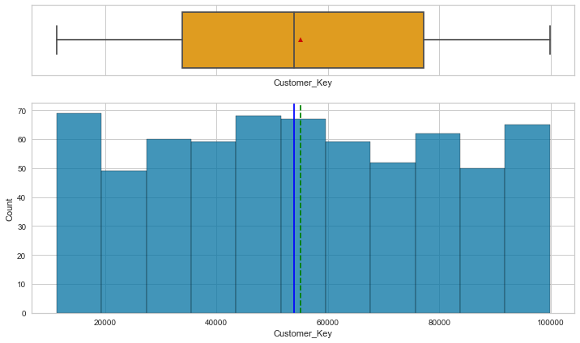

```python
# use the defined function histogram_boxplot to plot the graphs
histogram_boxplot(df,"Customer_Key")
```

**Observations:**

Customer_Key shows uniform distribution and has balanced data.

### Avg_Credit_Limit

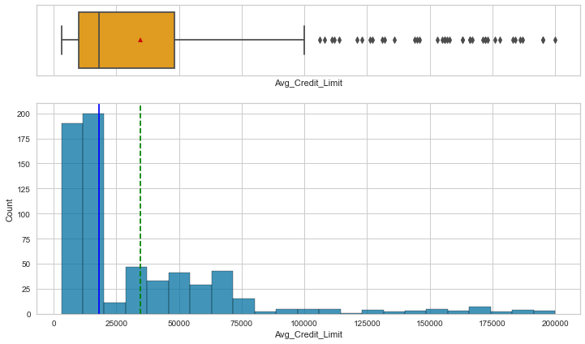

```python
# use the defined function histogram_boxplot to plot the graphs
histogram_boxplot(df,"Avg_Credit_Limit")
```

**Observations:**

1. Avg_Credit_Limit shows heavily rightward skewness.
2. Considering the domain the data is continuos and legitimate.
3. No outliers treatment required.

### Total_Credit_Cards

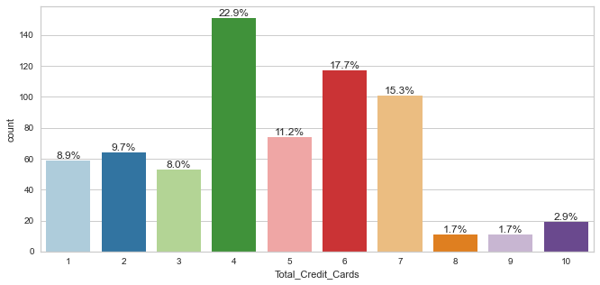

```python
# use label_barplot function to plot the graph
labeled_barplot(df,"Total_Credit_Cards", True, False)
```

**Observations:**

1. Approxmiately 23% customers hold 4 credit cards.
2. Followed by customers with 6 and 7 credit cards.
3. There are few customers having more than 7 cards.

### Total_visits_bank

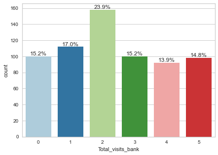

```python
# use label_barplot function to plot the graph
labeled_barplot(df,"Total_visits_bank", True, False)
```

**Observations:**

### Total_visits_online

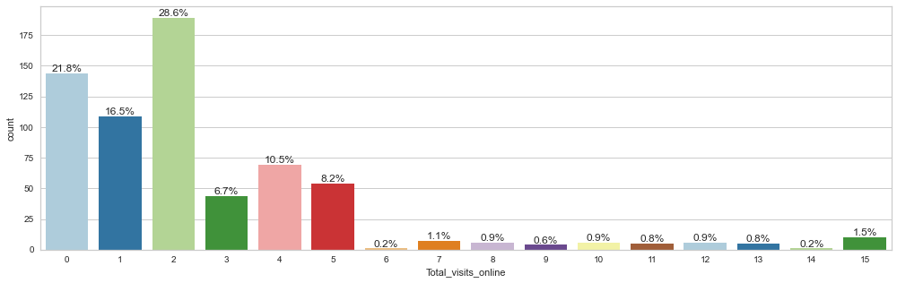

```python
# use label_barplot function to plot the graph
labeled_barplot(df,"Total_visits_online", True, False)
```

**Obervations:**

### Total_calls_made

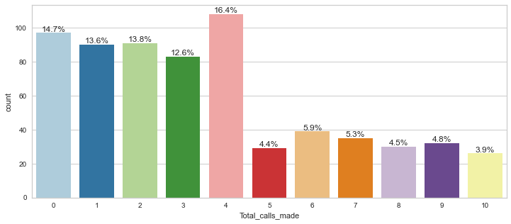

```python
# use label_barplot function to plot the graph
labeled_barplot(df,"Total_calls_made", True, False)
```

**Observations:**

1. 16.4% customers have called the bank 4 times for queries.
2. There is smaller segment of customers who need more interactions and have called bank 10 times.

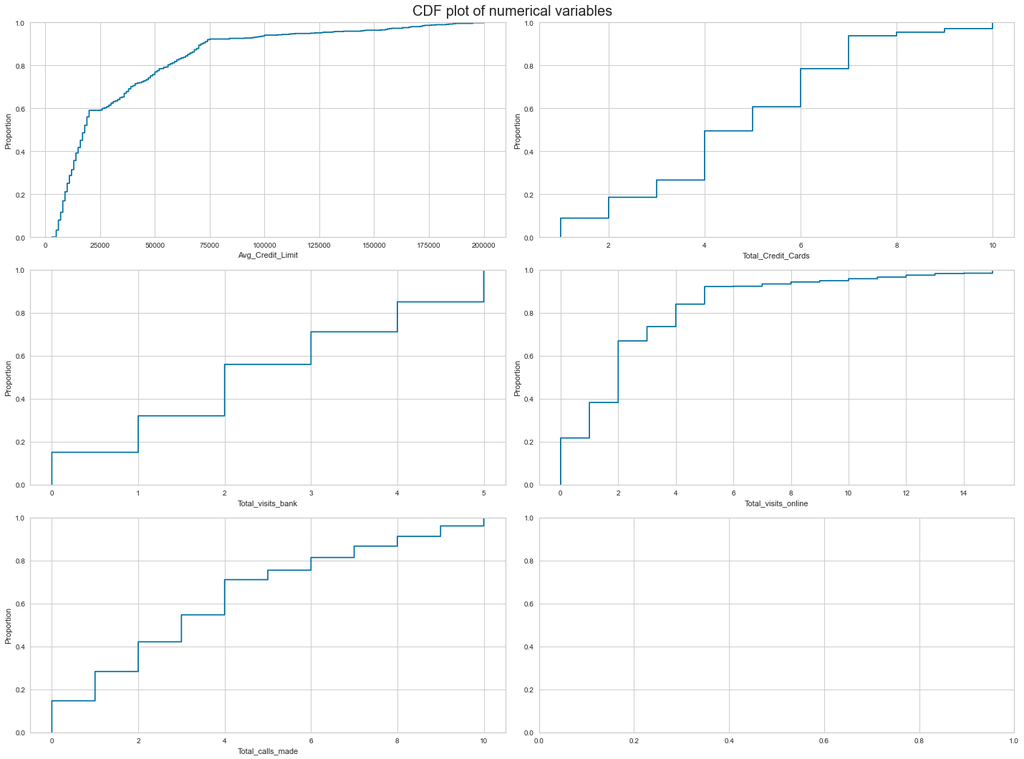

```python
# selecting numerical columns
num_cols = ['Avg_Credit_Limit', 'Total_Credit_Cards', 'Total_visits_bank', 'Total_visits_online', 'Total_calls_made']

# ploting cdf for numerical values
fig, axes = plt.subplots(3, 2, figsize=(20, 15))
fig.suptitle("CDF plot of numerical variables", fontsize=20)
counter = 0
for i in range(3):
    sns.ecdfplot(ax=axes[i][0], x=df[num_cols[counter]])
    counter = counter + 1
    if counter != 5:
        sns.ecdfplot(ax=axes[i][1], x=df[num_cols[counter]])
        counter = counter + 1
    else:
        pass

fig.tight_layout(pad=1.0)
```

**Observations:**

## Bivariate Analysis

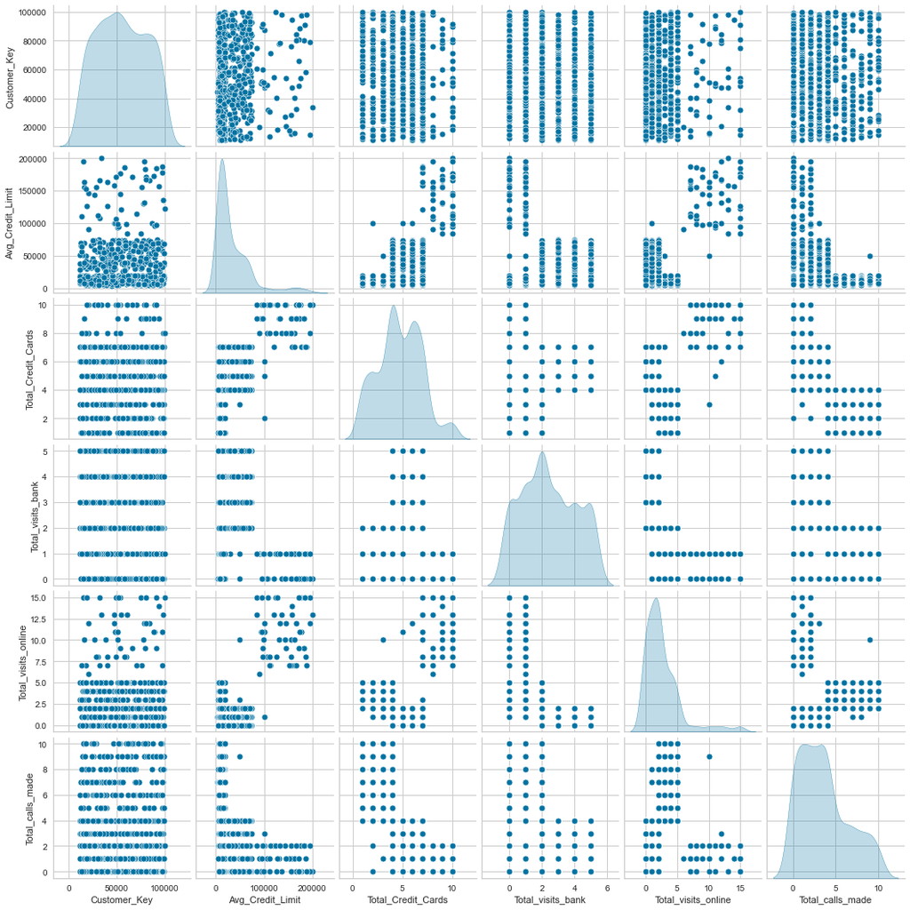

```python
# pairplot for all variables other than Customer_Key
sns.pairplot(df, diag_kind='kde');
```

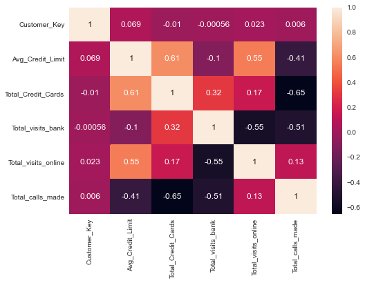

```python
# heatmap for all variables other than Customer_Key
sns.heatmap(df.corr(), annot=True);
```

**Observations:**

## Multivariate Analysis

### Comparision of various contact methods

```python
# Create a 3d scatter with clusters
fig = px.scatter_3d(df,
                    x = 'Total_visits_bank',
                    y = 'Total_visits_online',
                    z = 'Total_calls_made',
                    color= 'Total_Credit_Cards',
                    opacity = 0.8,)

fig.update_layout(margin=dict(l=0, r=0, b=0, t=20))
fig.show()
```

**Observations:**

## Outliers Treatment

### Draw boxplot for outliers in numerical columns

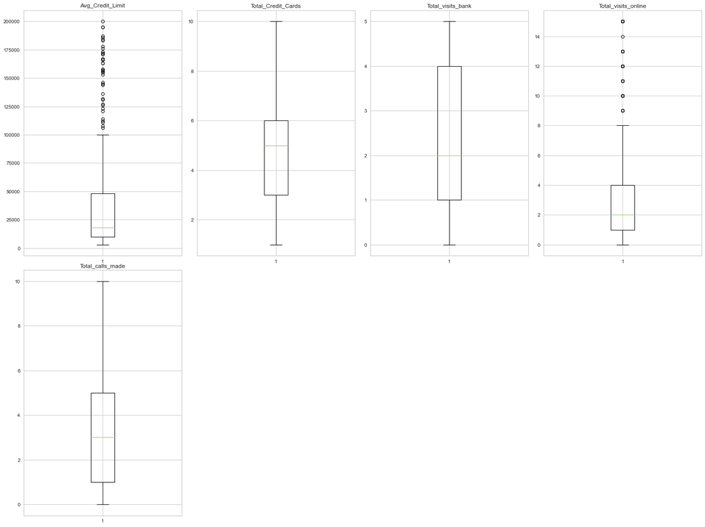

```python
# check the outliers before treating
plt.figure(figsize=(20, 15))

for i, variable in enumerate(num_cols):
    plt.subplot(2, 4, i + 1)
    plt.boxplot(df[variable], whis=1.5)
    plt.tight_layout()
    plt.title(variable)

plt.show()
```

**Observations:**

1. Avg_Credit_Limit and Total_visits_online show outliers.
2. Given the domain some customers will have higher credit limit.
3. Tech savvy customers use Bank's portal as their medium of contact for queries.

## Prepare Data for Clustering

### Scale the data for clustering

```python
# scaling the dataset before clustering
scaler = StandardScaler()
subset = df.copy()
subset_scaled = scaler.fit_transform(subset)

# creating a dataframe of the scaled columns for clustering
subset_scaled_df = pd.DataFrame(subset_scaled, columns=subset.columns)
```

## K-Means Clustering

### Find the approriate value for K using Kmeans

```python
# define cluster range
clusters = range(1, 10)
meanDistortions = []

# loop through the clusters
for k in clusters:
    model = KMeans(n_clusters=k)
    model.fit(subset_scaled_df)
    prediction = model.predict(subset_scaled_df)
    distortion = (
        sum(
            np.min(cdist(subset_scaled_df, model.cluster_centers_, "euclidean"), axis=1)
        )
        / subset_scaled_df.shape[0]
    )

    meanDistortions.append(distortion)

    print("Number of Clusters:", k, "\tAverage Distortion:", distortion)
```

```
Number of Clusters: 1 	Average Distortion: 2.2569539857353345
Number of Clusters: 2 	Average Distortion: 1.7858322163326603
Number of Clusters: 3 	Average Distortion: 1.505531485649799
Number of Clusters: 4 	Average Distortion: 1.363222352950455
Number of Clusters: 5 	Average Distortion: 1.272651786882213
Number of Clusters: 6 	Average Distortion: 1.2193964526252834
Number of Clusters: 7 	Average Distortion: 1.179708776175179
Number of Clusters: 8 	Average Distortion: 1.1449240646938936
Number of Clusters: 9 	Average Distortion: 1.1255011153786876
```

### Plot the Elbow Curve

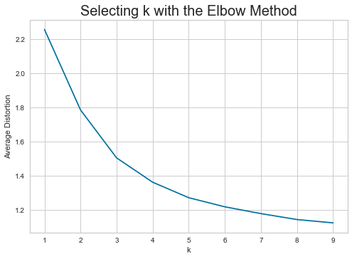

```python
# plot elbow graph
plt.plot(clusters, meanDistortions, "bx-")
plt.xlabel("k")
plt.ylabel("Average Distortion")
plt.title("Selecting k with the Elbow Method", fontsize=20)
```

**Observations:**

The appropriate value for K from the above graph seems to be 3 and 4

### Check the sihouette scores

```python
# check the silhouette scores
sil_score_km = []
cluster_list = list(range(2, 10))
for n_clusters in cluster_list:
    clusterer = KMeans(n_clusters=n_clusters)
    preds = clusterer.fit_predict((subset_scaled_df))
    # centers = clusterer.cluster_centers_
    score = silhouette_score(subset_scaled_df, preds)
    sil_score_km.append(score)
    print("For n_clusters = {}, silhouette score is {}".format(n_clusters, score))
```

```
For n_clusters = 2, silhouette score is 0.33817196365464486
For n_clusters = 3, silhouette score is 0.4177434852377372
For n_clusters = 4, silhouette score is 0.3228907072652812
For n_clusters = 5, silhouette score is 0.28484788872088673
For n_clusters = 6, silhouette score is 0.25411923510972967
For n_clusters = 7, silhouette score is 0.243077884075864
For n_clusters = 8, silhouette score is 0.22845120243547476
For n_clusters = 9, silhouette score is 0.20799268315275324
```

### Plot a graph for Silhouette Scores

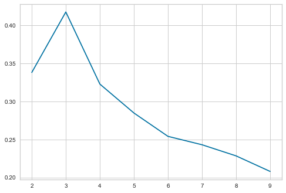

```python
# plot the graph
plt.plot(cluster_list, sil_score_km)
```

**Observations:**

### Find the optimal number of clusters

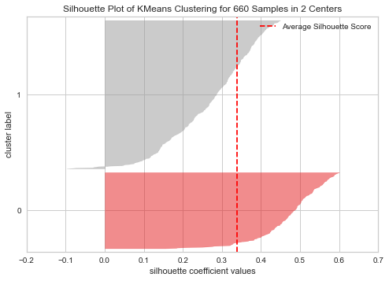

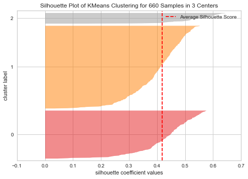

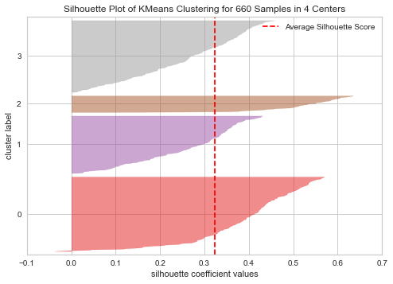

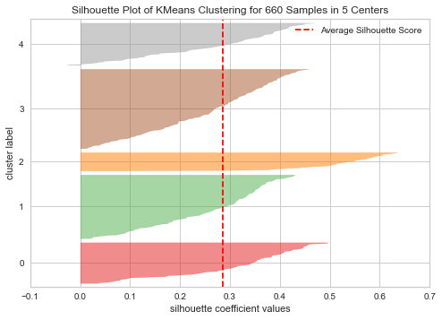

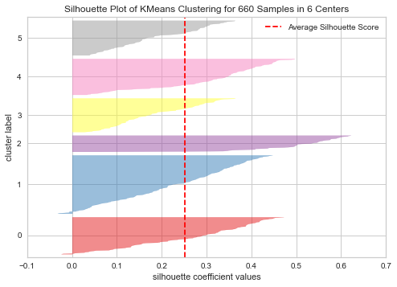

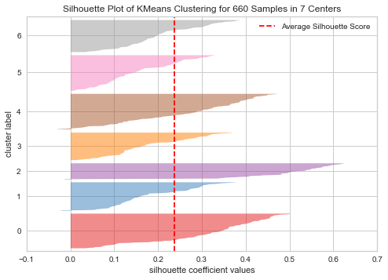

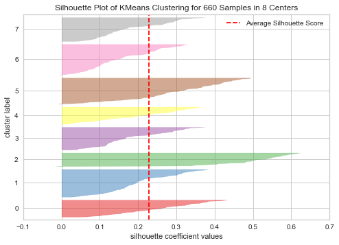

```python
# finding optimal no. of clusters with silhouette coefficients
num_list = list(range(2, 9))
for num in num_list:
    visualizer = SilhouetteVisualizer(KMeans(num, random_state=1))
    visualizer.fit(subset_scaled_df)
    visualizer.show()
```

**Observations:**

1. From the silhouette scores and other graphs, 3 appears to be the optimum value for K.
2. The silhouette score is high enough for 3.
3. The elbow curve also shows that the curve starts normalising at 3.

### Kmeans for 3 clusters

```python
# fit kmeans for 3 clusters
kmeans = KMeans(n_clusters=3, random_state=1)
kmeans.fit(subset_scaled_df)

# adding kmeans cluster labels to the original dataframe
df["KM_Clusters"] = kmeans.labels_

# find mean for each group
cluster_profile = df.groupby("KM_Clusters").mean()

# counts for each group
cluster_profile["count_in_each_segment"] = (
    df.groupby("KM_Clusters")["Customer_Key"].count().values
)

# let's display cluster profiles
cluster_profile.style.highlight_max(color="blue", axis=0)
```

| KM_Clusters | Customer_Key | Avg_Credit_Limit | Total_Credit_Cards | Total_visits_bank | Total_visits_online | Total_calls_made | count_in_each_segment |
| --- | --- | --- | --- | --- | --- | --- | --- |
| 0 | 55239.830357 | 12174.107143 | 2.410714 | 0.933036 | 3.553571 | 6.870536 | 224 |
| 1 | 54881.329016 | 33782.383420 | 5.515544 | 3.489637 | 0.981865 | 2.000000 | 386 |
| 2 | 56708.760000 | 141040.000000 | 8.740000 | 0.600000 | 10.900000 | 1.080000 | 50 |

**Observations:**

1. Cluster 2 has the highest value for Avg_Credit_Limit,Total_Credit_Cards & Total_visits_online.
2. Cluster 2 has the lowest value for Total_visits_bank.
3. Cluster 1 has the highest value for Total_visits_bank.
4. Cluster 1 has the lowest value for Total_visits_online.
5. Cluster 0 has the lowest value for Avg_Credit_Limit & Total_Credit_Cards.
6. Cluster 0 has the highest value for Total_calls_made.

### Visualise the clusters

#### 3D Scatter Plot for K_Means clusters

```python
# Create a 3d scatter with clusters
fig = px.scatter_3d(df,
                    x = 'Total_visits_bank',
                    y = 'Total_visits_online',
                    z = 'Total_calls_made',
                    color='KM_Clusters',
                    opacity = 0.8,)

fig.update_layout(margin=dict(l=0, r=0, b=0, t=20))
fig.show()
```

#### Box plots for K_Means clusters

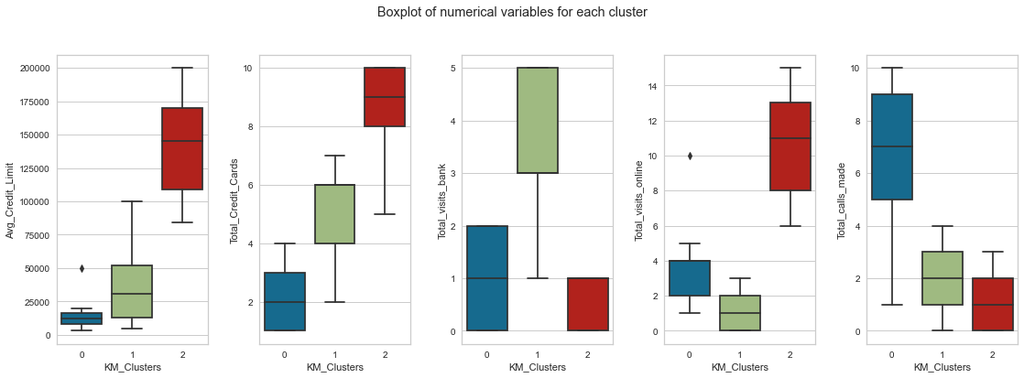

```python
# boxplot for numerical variables in each cluster
fig, axes = plt.subplots(1, 5, figsize=(16, 6))
fig.suptitle("Boxplot of numerical variables for each cluster")
counter = 0
for i in range(5):
    sns.boxplot(ax=axes[i], y=df[num_cols[counter]], x=df["KM_Clusters"])
    counter = counter + 1

fig.tight_layout(pad=2.0)
```

**Observations:**

Cluster 0:

- Customers who have average credit limit below 25k and own credit cards 1-4 max.
- Customers who seldom visit bank 0-2 times.
- Customers who visit bank online moderately (1-5 times)
- Customers who make most phone calls (4-10 times)
- 34% of customers are in this group.

Cluster 1:

Cluster 2:

## Hierarchical Clustering

```python
# list of distance metrics
distance_metrics = ["euclidean", "chebyshev", "mahalanobis", "cityblock"]

# list of linkage methods
linkage_methods = ["single", "complete", "average", "weighted"]

high_cophenet_corr = 0
high_dm_lm = [0, 0]

for dm in distance_metrics:
    for lm in linkage_methods:
        Z = linkage(subset_scaled_df, metric=dm, method=lm)
        c, coph_dists = cophenet(Z, pdist(subset_scaled_df))
        print(
            "Cophenetic correlation for {} distance and {} linkage is {}.".format(
                dm.capitalize(), lm, c
            )
        )
        if high_cophenet_corr < c:
            high_cophenet_corr = c
            high_dm_lm[0] = dm
            high_dm_lm[1] = lm
```

```
Cophenetic correlation for Euclidean distance and single linkage is 0.715826147503084.
Cophenetic correlation for Euclidean distance and complete linkage is 0.8333358686900459.
Cophenetic correlation for Euclidean distance and average linkage is 0.8684228720933057.
Cophenetic correlation for Euclidean distance and weighted linkage is 0.8642251666438747.
Cophenetic correlation for Chebyshev distance and single linkage is 0.6993328509872334.
Cophenetic correlation for Chebyshev distance and complete linkage is 0.7832281429250633.
Cophenetic correlation for Chebyshev distance and average linkage is 0.8628342866871905.
Cophenetic correlation for Chebyshev distance and weighted linkage is 0.8345913036690694.
Cophenetic correlation for Mahalanobis distance and single linkage is 0.6829750720107939.
Cophenetic correlation for Mahalanobis distance and complete linkage is 0.6051316784974622.
Cophenetic correlation for Mahalanobis distance and average linkage is 0.7754307051655684.
Cophenetic correlation for Mahalanobis distance and weighted linkage is 0.7777104249754613.
Cophenetic correlation for Cityblock distance and single linkage is 0.7109246213997495.
Cophenetic correlation for Cityblock distance and complete linkage is 0.8375342776656125.
Cophenetic correlation for Cityblock distance and average linkage is 0.8648270854737592.
Cophenetic correlation for Cityblock distance and weighted linkage is 0.8583676558565547.
```

#### Find highest cophenetic correlation from all methods

```python
# printing the combination of distance metric and linkage method with the highest cophenetic correlation
print(
    "Highest cophenetic correlation is {}, which is obtained with {} distance and {} linkage.".format(
        high_cophenet_corr, high_dm_lm[0].capitalize(), high_dm_lm[1]
    )
)
```

```
Highest cophenetic correlation is 0.8684228720933057, which is obtained with Euclidean distance and average linkage.
```

### Use Euclidean distance to analyse different linkage methods

```python
# list of linkage methods
linkage_methods = ["single", "complete", "average", "centroid", "ward", "weighted"]

high_cophenet_corr = 0
high_dm_lm = [0, 0]

for lm in linkage_methods:
    Z = linkage(subset_scaled_df, metric="euclidean", method=lm)
    c, coph_dists = cophenet(Z, pdist(subset_scaled_df))
    print("Cophenetic correlation for {} linkage is {}.".format(lm, c))
    if high_cophenet_corr < c:
        high_cophenet_corr = c
        high_dm_lm[0] = "euclidean"
        high_dm_lm[1] = lm
```

```
Cophenetic correlation for single linkage is 0.715826147503084.
Cophenetic correlation for complete linkage is 0.8333358686900459.
Cophenetic correlation for average linkage is 0.8684228720933057.
Cophenetic correlation for centroid linkage is 0.8656427328161594.
Cophenetic correlation for ward linkage is 0.7067190998109724.
Cophenetic correlation for weighted linkage is 0.8642251666438747.
```

#### Find highest cophenetic correlation with Euclidean distance

```python
# printing the combination of distance metric and linkage method with the highest cophenetic correlation
print(
    "Highest cophenetic correlation is {}, which is obtained with {} linkage.".format(
        high_cophenet_corr, high_dm_lm[1]
    )
)
```

```
Highest cophenetic correlation is 0.8684228720933057, which is obtained with average linkage.
```

**Observations**

We see that the cophenetic correlation is maximum with Euclidean distance and average linkage.

### Draw Dendograms for different methods

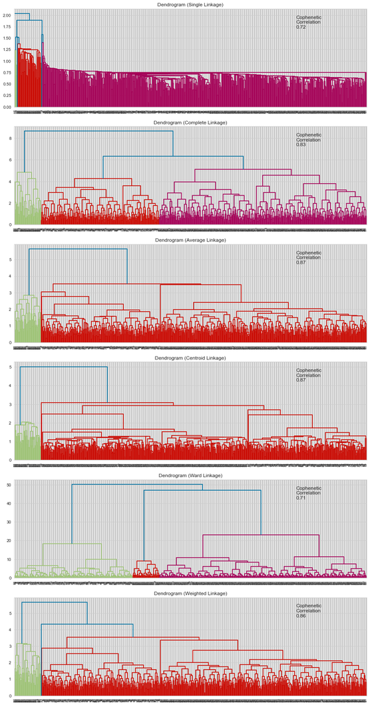

```python
# list of linkage methods
linkage_methods = ["single", "complete", "average", "centroid", "ward", "weighted"]

# lists to save results of cophenetic correlation calculation
compare_cols = ["Linkage", "Cophenetic Coefficient"]
compare = []

# to create a subplot image
fig, axs = plt.subplots(len(linkage_methods), 1, figsize=(15, 30))

# We will enumerate through the list of linkage methods above
# For each linkage method, we will plot the dendrogram and calculate the cophenetic correlation
for i, method in enumerate(linkage_methods):
    Z = linkage(subset_scaled_df, metric="euclidean", method=method)

    dendrogram(Z, ax=axs[i])
    axs[i].set_title(f"Dendrogram ({method.capitalize()} Linkage)")

    coph_corr, coph_dist = cophenet(Z, pdist(subset_scaled_df))
    axs[i].annotate(
        f"Cophenetic\nCorrelation\n{coph_corr:0.2f}",
        (0.80, 0.80),
        xycoords="axes fraction",
    )

    compare.append([method, coph_corr])
```

**Observations:**

Dendrogram for Ward linkage shows distinct and separate clusters.

### Create dataframe and compare cophenetic correlations

```python
# let's create a dataframe to compare cophenetic correlations for each linkage method
df_cc = pd.DataFrame(compare, columns=compare_cols)
df_cc
```

|  | Linkage | Cophenetic Coefficient |
| --- | --- | --- |
| 0 | single | 0.715826 |
| 1 | complete | 0.833336 |
| 2 | average | 0.868423 |
| 3 | centroid | 0.865643 |
| 4 | ward | 0.706719 |
| 5 | weighted | 0.864225 |

### Draw dendrogram for Mahalanobis and Manhattan distances with average and weighted linkage methods (as they gave high cophenetic correlation values).

**Centroid dendogram can only be created using Euclidean distance and we have already done that**

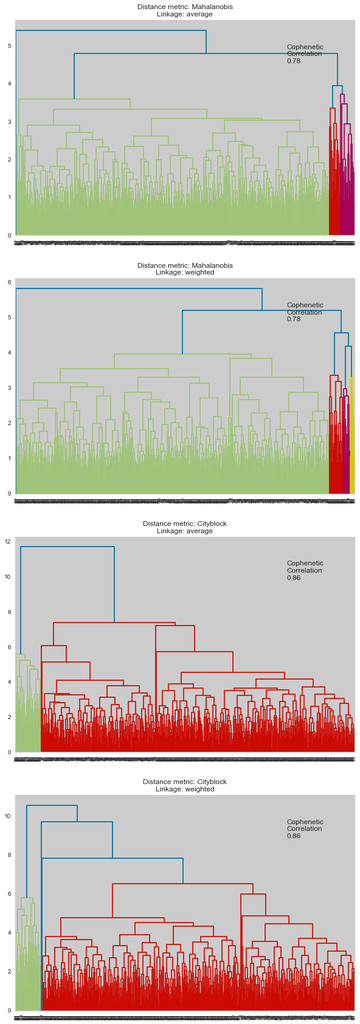

```python
# list of distance metrics
distance_metrics = ["mahalanobis", "cityblock"]

# list of linkage methods
linkage_methods = ["average", "weighted"]

# to create a subplot image
fig, axs = plt.subplots(
    len(distance_metrics) + len(distance_metrics), 1, figsize=(10, 30)
)

i = 0
for dm in distance_metrics:
    for lm in linkage_methods:
        Z = linkage(subset_scaled_df, metric=dm, method=lm)

        dendrogram(Z, ax=axs[i])
        axs[i].set_title("Distance metric: {}\nLinkage: {}".format(dm.capitalize(), lm))

        coph_corr, coph_dist = cophenet(Z, pdist(subset_scaled_df))
        axs[i].annotate(
            f"Cophenetic\nCorrelation\n{coph_corr:0.2f}",
            (0.80, 0.80),
            xycoords="axes fraction",
        )
        i += 1
```

**Observations**

1. Out of all the dendrograms we saw, it is clear that the dendrogram with Ward linkage gave us separate and distinct clusters.
2. 3 would be the appropriate number of the clusters from the dendrogram with Ward linkage method.

### Check the silhoutte scores

```python
# check the silhouette scores
sil_score_hc = []
cluster_list = list(range(2, 10))
for n_clusters in cluster_list:
    clusterer = AgglomerativeClustering(n_clusters=n_clusters)
    preds = clusterer.fit_predict((subset_scaled_df))
    # centers = clusterer.cluster_centers_
    score = silhouette_score(subset_scaled_df, preds)
    sil_score_hc.append(score)
    print("For n_clusters = {}, silhouette score is {}".format(n_clusters, score))
```

```
For n_clusters = 2, silhouette score is 0.33811250832687806
For n_clusters = 3, silhouette score is 0.41782525470042764
For n_clusters = 4, silhouette score is 0.31213889088706714
For n_clusters = 5, silhouette score is 0.2729797232608641
For n_clusters = 6, silhouette score is 0.2382147994519145
For n_clusters = 7, silhouette score is 0.20973866896049975
For n_clusters = 8, silhouette score is 0.19754523680023992
For n_clusters = 9, silhouette score is 0.17604761610726194
```

### Plot a graph for Silhouette Scores

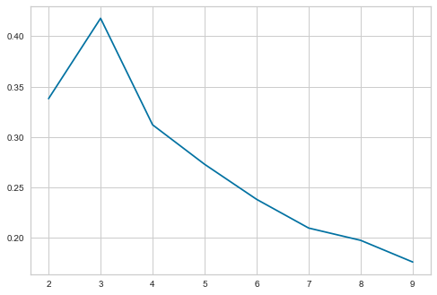

```python
# plot the graph
plt.plot(cluster_list, sil_score_hc)
```

### Create 3 Clusters using AgglomerativeClustering

```python
# instantiate model
HCmodel = AgglomerativeClustering(n_clusters=3, affinity="euclidean", linkage="ward")
HCmodel.fit(subset_scaled_df)

# adding hierarchical cluster labels to the original dataframe
df["HC_Clusters"] = HCmodel.labels_

cluster_profile = df.groupby("HC_Clusters").mean()

cluster_profile["count_in_each_segments"] = (
    df.groupby("HC_Clusters")["Customer_Key"].count().values
)

# let's display cluster profiles
cluster_profile.style.highlight_max(color="red", axis=0)
```

| HC_Clusters | Customer_Key | Avg_Credit_Limit | Total_Credit_Cards | Total_visits_bank | Total_visits_online | Total_calls_made | KM_Clusters | count_in_each_segments |
| --- | --- | --- | --- | --- | --- | --- | --- | --- |
| 0 | 54829.721649 | 33688.144330 | 5.505155 | 3.476804 | 0.987113 | 2.002577 | 0.994845 | 388 |
| 1 | 55333.256757 | 12144.144144 | 2.400901 | 0.932432 | 3.567568 | 6.909910 | 0.000000 | 222 |
| 2 | 56708.760000 | 141040.000000 | 8.740000 | 0.600000 | 10.900000 | 1.080000 | 2.000000 | 50 |

**Observations:**

### Visualise the Clusters

**3D Scatter Plot highlighting HC_Clusters**

```python
# Create a 3d scatter with clusters
fig = px.scatter_3d(df,
                    x = 'Total_visits_bank',
                    y = 'Total_visits_online',
                    z = 'Total_calls_made',
                    color='HC_Clusters',
                    opacity = 0.8,)

fig.update_layout(margin=dict(l=0, r=0, b=0, t=20))
fig.show()
```

**Boxplot for HC_Clusters**

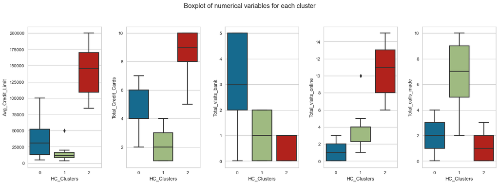

```python
# boxplot for numerical variables in each cluster
fig, axes = plt.subplots(1, 5, figsize=(16, 6))
fig.suptitle("Boxplot of numerical variables for each cluster")
counter = 0
for i in range(5):
    sns.boxplot(ax=axes[i], y=df[num_cols[counter]], x=df["HC_Clusters"])
    counter = counter + 1

fig.tight_layout(pad=2.0)
```

**Observations:**

Cluster 0:

Cluster 1:

- Customers who have average credit below 25k and own credit cards 1-4 max.
- Customers who seldom visit bank 0-2 times.
- Customers who visit bank online moderately (1-5 times)
- Customers who make most phone calls (4-10 times)
- 34% of customers are in this group.

Cluster 2:

- Customers who have average credit limit above 75k and own most credit cards 5-10 max.
- Customers who least visited bank 0-1 times.
- Customers who most visit bank online . (6-15 times)
- Customers who make least phone calls (0-2 times)
- Only 7.5% of customers are in this group.

### K Means and Heirarchical Clustering - Compared

### Compare the findings

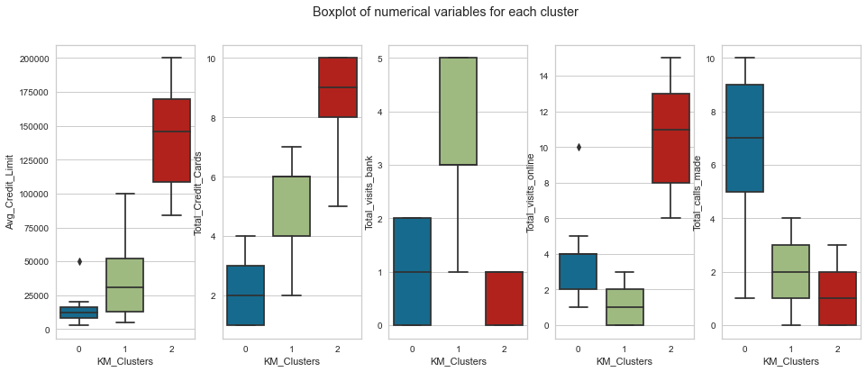

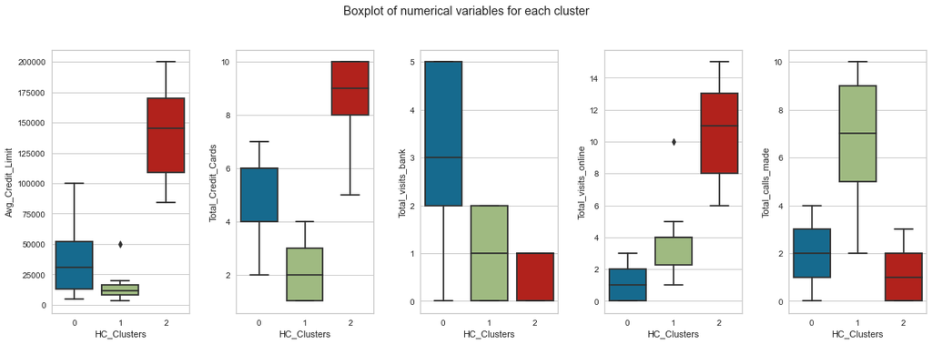

```python
# boxplot for numerical variables in each cluster
fig, axes = plt.subplots(1, 5, figsize=(16, 6))
fig.suptitle("Boxplot of numerical variables for each cluster")
counter = 0
for i in range(5):
    sns.boxplot(ax=axes[i], y=df[num_cols[counter]], x=df["KM_Clusters"])
    counter = counter + 1

# boxplot for numerical variables in each cluster
fig, axes = plt.subplots(1, 5, figsize=(16, 6))
fig.suptitle("Boxplot of numerical variables for each cluster")
counter = 0
for i in range(5):
    sns.boxplot(ax=axes[i], y=df[num_cols[counter]], x=df["HC_Clusters"])
    counter = counter + 1

fig.tight_layout(pad=2.0)
```

### Compare the Silhouette Scores

```python
# create dataframe
comparison_frame = pd.DataFrame({"Clusters":["2","3","4","5","6",
                                          "7","8","9"],
                                          "KMeans Score": sil_score, "HC Scores": sil_score_hc
                                         })
comparison_frame
```

[output not shown]

**Observations:**

1. K-Means Clustering executes faster than Heirarchical Clustering.
2. Both methods recommend 3 clusters as ideal for classification based on Communicatin method.
3. Cluster 2 identified by both clustering mechanism is same - 7.5% of customers.
4. Findings for Cluster 0 and Cluster 1 are changed.
5. Both methods return similar Silhouette scores.

## Conclusion

There are three distinct categories of customers:

[output not shown]

There are 5 sets of records for customers with entries that have changed over time:

```
* We can see that in three of the five cases customers have moved from one cluster to another.
* It looks like case one possible choice is to incentivize customers to change to a more desirable class.
* Bank may want more customers to switch to digital, as they are more engaged (have more visits) and have more credit cards.
```

## Recommendations

**Based on K-Means Clustering:**

**Based on Heirarchical Clustering:**

**Others:**

1. Business can tailor contact methods to the customer preferences:
   - Online/phone users will probably prefer email/text notifications
   - While in-person users mail prefer mail notifications and upselling (when at the bank location).
   - Since online users tend to have (and presumably use) the most credit, these may be the demographic business would want to target with next ad campaign, focusing on digit recruiting.
2. Bank to start monitoring usage that indicates a state change so that the contact methods are changed according to customer preferences.
3. Since both clustering methods are classifying customers based on the Communication Method that customer uses to interact with bank, Business can choose either of the mechanism and implement recommendations based on the chosen clustering.

```python
# Module : Unsupervised Learning
# Project: AllLife Bank Customer Segmentation
# Submitted by : Ritesh Sharma
# Submission Date : 19 Nov 2021
```